# Audit: World Bank Pink Sheet and the municipal price indices

Published

October 10, 2026

Source: World Bank Commodity Markets Outlook, Commodity Price Data (The Pink Sheet), `CMO-Historical-Data-Annual.xlsx`, release of 2026-09-02, downloaded 2026-10-10 (`_data/raw/worldbank/`), sheet Annual Prices (Real), 2010 US dollars deflated by the MUV index. Pipeline script: `_scripts/03-controls-prices.R` (weights from `03-controls-agro.R`). Interim outputs: `_data/interim/prices_real_normalized_2000_2020.rds`, `prices_index_2000_2020.rds`. Equivalence with the recovered panel is not checked here (the notebook never reads `_data/reference/`); the `compare_outputs` report lives in the phase 1 script 03 commit message and in the decision entries it cites.

```r
pink_raw <- read_excel("_data/raw/worldbank/CMO-Historical-Data-Annual.xlsx",
                       sheet = "Annual Prices (Real)", col_names = FALSE, col_types = "text",
                       .name_repair = "minimal")
prices_norm <- read_rds("_data/interim/prices_real_normalized_2000_2020.rds")
prices_index <- read_rds("_data/interim/prices_index_2000_2020.rds")
weights <- read_rds("_data/interim/pam_ppm_weights_base_2000_2002.rds")
sample_geo <- read_rds("_data/interim/mapbiomas_deforestation_amz_1987_2023.rds") %>%
  distinct(geocode, municipality, state_abbreviation)
```

## Q1. What is the layout and the release of the workbook?

```r
excel_sheets("_data/raw/worldbank/CMO-Historical-Data-Annual.xlsx")
```

```
[1] "Cover"                    "Annual Prices (Nominal)"  "Annual Indices (Nominal)"
[4] "Annual Prices (Real)"     "Annual Indices (Real)"    "Description"
[7] "Definitions"              "Index Weights"
```

```r
pink_raw[1:4, 1]
```

```
# A tibble: 4 × 1
  ``
  <chr>
1 World Bank Commodity Price Data (The Pink Sheet)
2 annual prices, 1960 to present, real 2010 US dollars
3 (annual series are available in nominal and real dollars)
4 Updated on September 02, 2026
```

```r
series <- c("Soybeans", "Maize", "Rice, Thai 5%", "Cotton, A Index", "Beef")
idx <- match(series, str_trim(unlist(pink_raw[7, ])))
tibble(series, column = idx, unit = str_trim(unlist(pink_raw[8, idx])),
       first_year = pink_raw[[1]][9], last_year = pink_raw[[1]][nrow(pink_raw)])
```

```
# A tibble: 5 × 5
  series          column unit   first_year last_year
  <chr>            <int> <chr>  <chr>      <chr>
1 Soybeans            25 ($/mt) 1960       2025
2 Maize               29 ($/mt) 1960       2025
3 Rice, Thai 5%       31 ($/mt) 1960       2025
4 Cotton, A Index     53 ($/kg) 1960       2025
5 Beef                40 ($/kg) 1960       2025
```

**Finding.** The sheet keeps the legacy layout: commodity names on row 7, units on row 8, data from row 9 (1960) to 2025, year in the first column. The release header reads “Updated on September 02, 2026”. The five series are present under their legacy names, soy, maize and rice in dollars per tonne, cotton and beef per kilogram. **Decision.** D-2026-10-10-a (release accepted; the real series are recomputed at each MUV revision, so the indices drift from the lost release by a fraction of a percent). **Assertion.** `03-controls-prices.R`, raw-state block (names, units, first year, complete 2000-2020).

## Q2. How do the normalised real series move over 2000-2020?

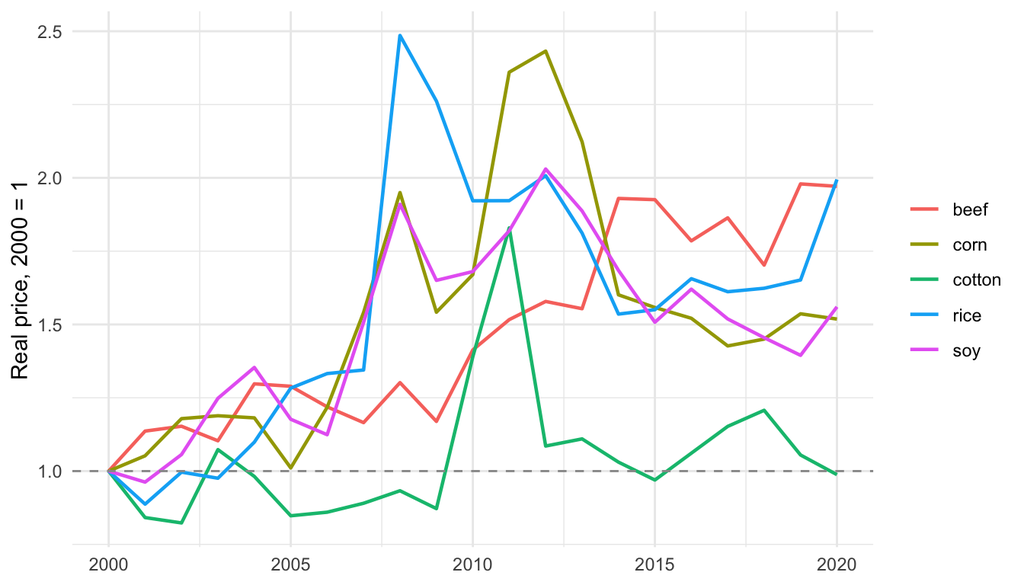

```r
prices_norm %>%
  pivot_longer(-year, names_to = "commodity", values_to = "index") %>%
  ggplot(aes(year, index, colour = commodity)) +
  geom_line(linewidth = 0.8) +
  geom_hline(yintercept = 1, linetype = "dashed", colour = "grey60") +
  labs(x = NULL, y = "Real price, 2000 = 1", colour = NULL) +
  theme_minimal()
```

```r
prices_norm %>% filter(year %in% c(2000, 2004, 2008, 2012, 2016, 2020))
```

```
# A tibble: 6 × 6
   year   soy  corn  rice cotton  beef
  <int> <dbl> <dbl> <dbl>  <dbl> <dbl>
1  2000  1     1     1     1      1
2  2004  1.35  1.18  1.10  0.982  1.30
3  2008  1.91  1.95  2.49  0.933  1.30
4  2012  2.03  2.43  2.01  1.09   1.58
5  2016  1.62  1.52  1.66  1.06   1.79
6  2020  1.56  1.52  1.99  0.988  1.97
```

## Q3. Is the index anchored to 1 in 2000 for both crop and cattle?

```r
prices_index %>%
  filter(geocode %in% sample_geo$geocode, year == 2000) %>%
  summarise(across(c(price_index_crop, price_index_cattle),
                   list(n_na = ~ sum(is.na(.x)), min = ~ min(.x, na.rm = TRUE),
                        p50 = ~ median(.x, na.rm = TRUE), max = ~ max(.x, na.rm = TRUE)))) %>%
  pivot_longer(everything(), names_to = c("index", "stat"),
               names_pattern = "(price_index_[a-z]+)_(n_na|min|p50|max)$") %>%
  pivot_wider(names_from = stat, values_from = value)
```

```
# A tibble: 2 × 5
  index               n_na   min      p50     max
  <chr>              <dbl> <dbl>    <dbl>   <dbl>
1 price_index_crop       4     0  0.00957   0.749
2 price_index_cattle     3     0 15.4     170.
```

```r
prices_index %>% filter(geocode == "1100015", year %in% 2000:2002) %>%
  left_join(weights, by = "geocode") %>%
  select(year, price_index_crop, price_index_cattle, cattle_weight)
```

```
# A tibble: 3 × 4
   year price_index_crop price_index_cattle cattle_weight
  <int>            <dbl>              <dbl>         <dbl>
1  2000           0.0111               33.8          33.8
2  2001           0.0112               38.4          33.8
3  2002           0.0126               38.9          33.8
```

## Q4. Are the scales comparable?

```r
prices_index %>%
  filter(geocode %in% sample_geo$geocode) %>%
  pivot_longer(starts_with("price_index"), names_to = "index", values_to = "value") %>%
  group_by(index) %>%
  summarise(n_na = sum(is.na(value)), min = min(value, na.rm = TRUE), p50 = median(value, na.rm = TRUE),
            max = max(value, na.rm = TRUE), sd = sd(value, na.rm = TRUE), .groups = "drop")
```

```
# A tibble: 3 × 6
  index                  n_na   min     p50    max      sd
  <chr>                 <int> <dbl>   <dbl>  <dbl>   <dbl>
1 price_index_cattle       63     0 22.3    336.   42.8
2 price_index_crop         84     0  0.0136   1.60  0.0892
3 price_index_crop_lag1   888     0  0.0135   1.60  0.0890
```

**Finding.** The cattle index is three orders of magnitude larger than the crop index and both carry the cross-sectional scale of the weights (a share of the territory against heads per km²), so the two coefficients are not comparable in raw units; script 04 standardises them. The scale difference is the unit of the exposures, not an error, and is left as is (D-2026-10-23-a); a pasture-share exposure for cattle would put both on the 0-1 scale (D-2026-10-23-c, Q7). **Decision.** D-2026-10-23-a; D-2026-10-23-c open.

## Q5. Which municipalities have a zero or missing index, and why?

```r
prices_index %>%
  filter(geocode %in% sample_geo$geocode, year == 2000,
         is.na(price_index_crop) | price_index_crop == 0 | is.na(price_index_cattle)) %>%
  left_join(weights, by = "geocode") %>%
  left_join(sample_geo, by = "geocode") %>%
  select(geocode, municipality, state_abbreviation, price_index_crop, price_index_cattle,
         starts_with("crop_w_"), cattle_weight)
```

```
# A tibble: 9 × 10
  geocode municipality           state_abbreviation price_index_crop price_index_cattle crop_w_soy crop_w_corn
  <chr>   <chr>                  <chr>                         <dbl>              <dbl>      <dbl>       <dbl>
1 1300409 Barcelos               AM                                0            0.00197          0           0
2 1303601 Santa Isabel do Rio N… AM                                0            0.00438          0           0
3 1304260 Uarini                 AM                                0            0.0425           0           0
4 1501402 Belém                  PA                                0            0.168            0           0
5 1504422 Marituba               PA                                0            8.01             0           0
6 1504752 Mojuí dos Campos       PA                               NA           NA               NA          NA
7 1506401 Santa Cruz do Arari    PA                               NA           33.8             NA          NA
8 5104526 Ipiranga do Norte      MT                               NA           NA               NA          NA
9 5104542 Itanhangá              MT                               NA           NA               NA          NA
# ℹ 3 more variables: crop_w_rice <dbl>, crop_w_cotton <dbl>, cattle_weight <dbl>
```

**Finding.** Nine sample municipalities have a zero or missing index in 2000. Five (Barcelos, Santa Isabel do Rio Negro and Uarini in Amazonas, Belém and Marituba in Pará) planted none of the four crops in 2000-2002, so their crop index is a true zero, a constant absorbed by the municipality effect. Ipiranga do Norte, Itanhangá and Mojuí dos Campos have no crop index (NA since phase 2 step 2.4; 0 in phase 1, when the weighted sum dropped their four NA weights) because they have no PAM value in the window, and no cattle index, their density weight being NA. Santa Cruz do Arari has no crop index, having no PAM series, and keeps its cattle index through the full join of the two indices. **Decision.** D-2026-10-10-h (true zero for an empty basket); D-2026-10-23-b (NA for an all-NA window); D-2026-10-10-i (Santa Cruz do Arari); task 1.8 for the remaining codings of absence. **Assertion.** `03-controls-prices.R`, output block (crop index NA exactly for municipalities whose four weights are missing; lag NA in 2000 or where the index is NA).

## Q6. What would anchoring each index at 2000 = 1 within the municipality do?

Task 1.3 planned to divide each municipality’s index by its own 2000 value (D-2026-10-05-p). The procedure was implemented on the step 2.4 branch and reversed; this section keeps the evidence. What is checked: the anchored values recomputed here for the sample, the municipalities that would have no anchor, the cross-sectional range of the anchored cattle index within a year, and the split of the anchored crop index’s variance between years and within years.

```r
anchored <- prices_index %>%
  filter(geocode %in% sample_geo$geocode) %>%
  group_by(geocode) %>%
  mutate(crop_base = price_index_crop[year == 2000],
         cattle_base = price_index_cattle[year == 2000],
         crop_a = if_else(crop_base > 0, price_index_crop / crop_base, NA_real_),
         cattle_a = if_else(cattle_base > 0, price_index_cattle / cattle_base, NA_real_)) %>%
  ungroup()
anchored %>%
  group_by(year) %>%
  summarise(crop_mean = mean(crop_a, na.rm = TRUE),
            crop_sd_within_year = sd(crop_a, na.rm = TRUE),
            cattle_mean = mean(cattle_a, na.rm = TRUE),
            cattle_range_within_year = diff(range(cattle_a, na.rm = TRUE)),
            n_munic_no_crop_anchor = sum(is.na(crop_a)),
            n_munic_no_cattle_anchor = sum(is.na(cattle_a)),
            .groups = "drop") %>%
  mutate(across(-year, ~ round(.x, 3))) %>%
  filter(year %in% c(2000, 2004, 2008, 2012, 2016, 2020))
```

```
# A tibble: 6 × 7
   year crop_mean crop_sd_within_year cattle_mean cattle_range_within_year n_munic_no_crop_anchor
  <int>     <dbl>               <dbl>       <dbl>                    <dbl>                  <dbl>
1  2000      1                  0            1                           0                      9
2  2004      1.16               0.045        1.30                        0                      9
3  2008      2.17               0.138        1.30                        0                      9
4  2012      2.21               0.112        1.58                        0                      9
5  2016      1.58               0.034        1.78                        0                      9
6  2020      1.73               0.111        1.97                        0                      9
# ℹ 1 more variable: n_munic_no_cattle_anchor <dbl>
```

```r
anchored %>%
  filter(!is.na(crop_a)) %>%
  mutate(year_mean = ave(crop_a, year)) %>%
  summarise(between_year_sd = round(sd(year_mean), 3),
            within_year_sd = round(sd(crop_a - year_mean), 3))
```

```
# A tibble: 1 × 2
  between_year_sd within_year_sd
            <dbl>          <dbl>
1           0.376          0.075
```

**Finding.** Anchoring cancels the exposure. The cattle index, built on one commodity, becomes the relative beef price in every municipality with a herd (zero range within a year), a pure year series that year effects absorb; the nine municipalities of the 503 with a zero or missing 2000 crop value (eight in the sample panel, Mojuí dos Campos being dropped) and the six with a zero or missing cattle value (five) would have no anchor and become NA. The anchored crop index keeps only the crop-mix variation: a within-year sd of about 0.07 against a between-year sd of about 0.38, intensity having cancelled. The exposure form that script 03 produces is the shift-share control the design asks for, and its 2000 level is absorbed by the municipality effect. **Decision.** D-2026-10-23-a: no anchoring; D-2026-10-05-p closed by reinterpretation. **Assertion.** none; the procedure was rejected.

## Q7. Can the cattle exposure be expressed as a pasture share from the raw layer?

A 2000-2002 pasture share of the territory would put the cattle exposure on the 0-1 scale of the crop shares. What is checked: whether the MapBiomas workbook in the raw layer carries land-cover classes.

```r
readxl::excel_sheets("_data/raw/mapbiomas/mapbiomas_munic.xlsx")
```

```
[1] "READ_ME"          "DEF_SECVEG"       "PIVOT_DEF_SECVEG" "METADADOS"
```

**Finding.** The workbook is the deforestation and secondary-vegetation module only: one data sheet (`DEF_SECVEG`, four transition names, see `mapbiomas.qmd` Q1), its pivot, a README and metadata; no land-cover class, so no pasture area. A pasture share needs a new acquisition (MapBiomas Collection 9 land-cover statistics by municipality, class 15, or the Censo Agropecuário 2006 pasture area). **Decision.** D-2026-10-23-c, open, reserved to the author. **Assertion.** none.